# ESM 206 A3 Task 3

Joaquin Meckler

11/1/2020

## Introduction

For this weeks lab, part 3 and 4 involve working with data provided by Santa Barbara Coastal LTER. This data contains observations collected by program divers along the Santa Barbara coast. The dataset and more information about how it was collected and by who can be found [here](https://portal.edirepository.org/nis/mapbrowse?packageid=knb-lter-sbc.26.20). To start, I downloaded the necessary packages. The new ones this time are *kableExtra*, which helps with summary tables, and *lubridate*, which helps with wrangling date columns within a table. In a quick anecdote that might amuse whoever is grading this, I consistently look at the word “urchin” and think it is misspelled. Anyway, after reading in the packages, I began to read in the data and take a look at the variables within it.

## Part 1

After reading in the data and using the clean names function, I created some exploratory data visualization graphs. These exploratory graphs are meant to be a quick snapshot look at the data and give some hints at where to focus my future exploratory efforts.

```r
urchin<-read_csv(here("data", "urchins.csv")) %>%
  clean_names()
```

### Exploratory Graph 1

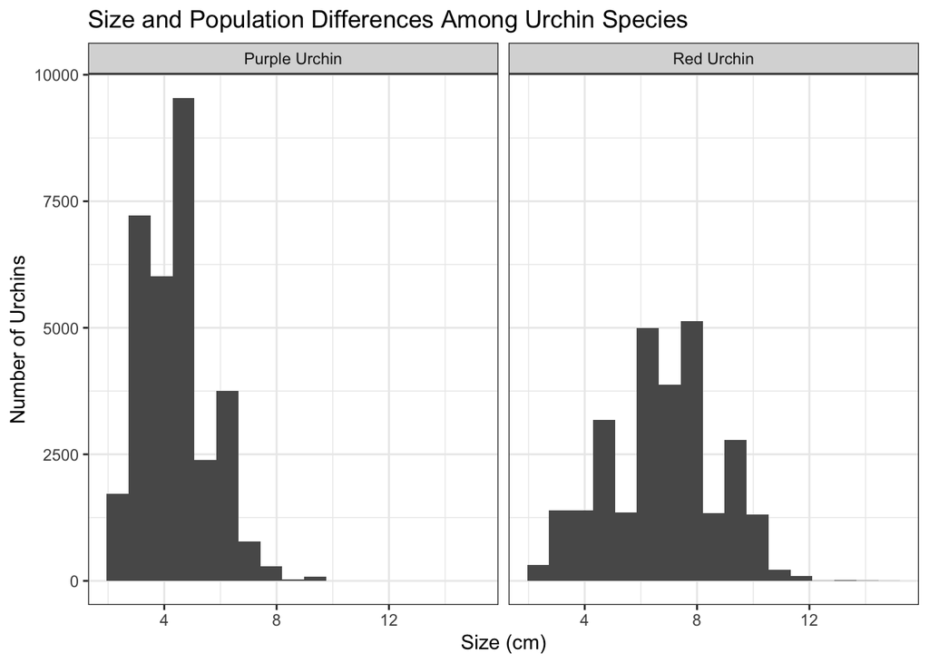

```r
ggplot(data=urchin, aes(x=size))+
  geom_histogram(bins=17)+ #ASK IF SHOULD INCLUDE BINS OR WHY THAT INCREASES TOTAL ON Y AXIS
  labs(x = "Size (cm)",
       y = "Number of Urchins",
       title= "Size and Population Differences Among Urchin Species")+
  facet_wrap(~common_name)+
  theme_bw()
```

In the above histogram, I wanted to better look at this distribution of sizes between urchin species. I was thinking about using the *bins=* function and decided it would be better to include since it was an exploratory graph. It quickly showed me the approximate differences in size and overall spread within each species. *Facet_wrap* allowed me to split it into different different charts within the graph.

### Exploratory Graph 2

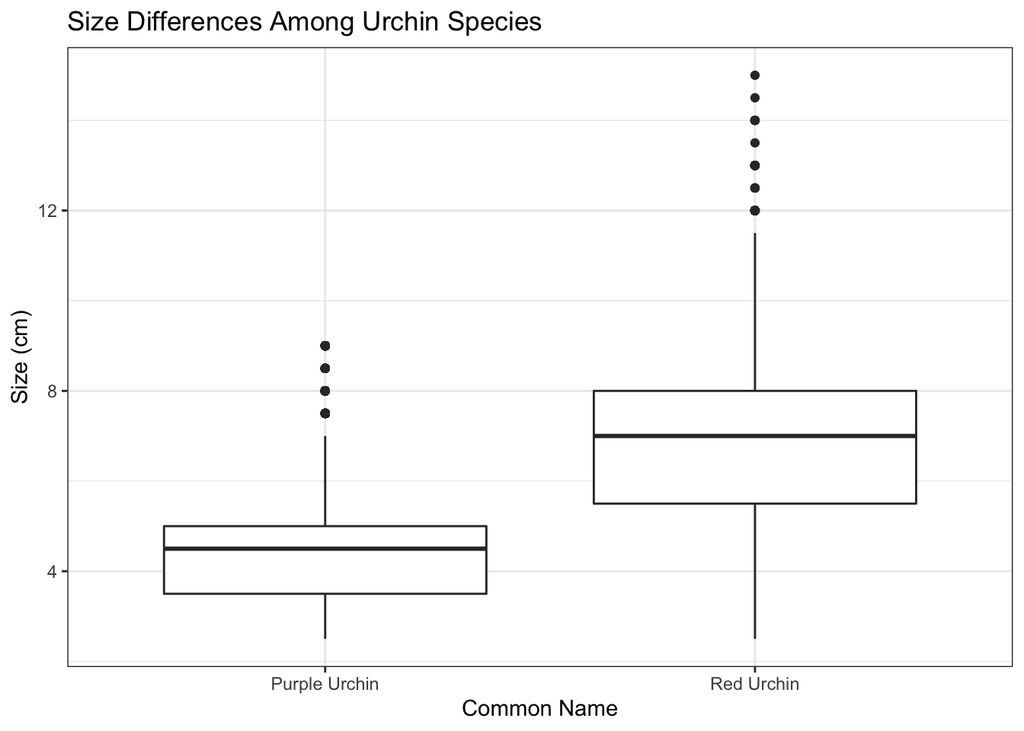

```r
ggplot(data=urchin, aes(x=common_name, y=size))+
  geom_boxplot()+
  labs(y = "Size (cm)",
       x = "Common Name",
       title= "Size Differences Among Urchin Species")+
  theme_bw()
```

## Part 2

Now that I had made a couple quick graphs, I wanted to view the data through a statistical lens. Using the *summarize* function, was able to get the mean, median, standard devation, and total number of observations for each speices. I used the *kable_styling* to make the knitted document look more appealing.

```r
urchin_summary<-urchin %>%
  group_by(common_name) %>%
  summarize(mean=mean(size), median=median(size), sd=sd(size), n=n())

kbl(urchin_summary) %>%
  kable_styling()
```

| common_name | mean | median | sd | n |
| --- | --- | --- | --- | --- |
| Purple Urchin | 4.469797 | 4.5 | 1.175264 | 31805 |
| Red Urchin | 6.776489 | 7.0 | 1.891343 | 27408 |

Now that I have a quick summary of mean, median, standard devation, and obersvation count, I can look at the percent difference and actual difference. To do this, I quickly created two different functions and then plugged in the numbers I got from the urchin_summary table to run the functions.

```r
pct_dif<-function(a,b){(b-a)/((a+b)/2)}
actual_dif<-function(a,b){b-a}

pct_dif(4.469797, 6.776489)
```

```
## [1] 0.410214
```

```r
actual_dif(4.469797, 6.776489)
```

```
## [1] 2.306692
```

## Takeaway

The actual difference red urchin mean being 2.3cm greater than the purple urchin mean, and the the percent difference of 41% further display the size disparity between species.

### Section 2

Now that I had the looked at just the size difference, I am going to look at size differences among the different sites but just for purple urchins. Since the sites are in abbreviations, I am using the *mutate* function and *lubridate* package to rename them to the full site names. I put all of this in a dataset called *purple_urchin*

Once complete, I ran the class function to see what form the data was in. Normally, I would just do this in the console but I figured its good to get into the habit and will remind me when I comeback to this script later.

```r
purple_urchins<-urchin %>%
  filter(common_name=="Purple Urchin") %>%
  mutate(Date=mdy(date)) %>%
  mutate(year=year(Date)) %>%
  mutate(site_full=case_when(
    site=="NAPL"~"Naples Reef",
    site=="AQUE" ~ "Arroyo Quemado Reef",
    site=="CARP" ~ "Carpinteria Reef",
    site== "MOHK"~ "Mohawk Reef",
    site== "IVEE"~ "Isla Vista Reef"
  ))

class(purple_urchins$Date)
```

```
## [1] "Date"
```

Similar to the earlier tasks, I want to view the summary of the observations of purple urchin by site by year. I called this *purple_urchins_summary*

```r
purple_urchins_summary<-purple_urchins %>%
    group_by(site_full, year) %>%
  count(year)
```

I made it *fancy* with kable_styling

```r
kbl(purple_urchins_summary) %>%
  kable_styling()
```

| site_full | year | n |
| --- | --- | --- |
| Arroyo Quemado Reef | 2008 | 67 |
| Arroyo Quemado Reef | 2009 | 926 |
| Arroyo Quemado Reef | 2010 | 921 |
| Arroyo Quemado Reef | 2011 | 887 |
| Arroyo Quemado Reef | 2012 | 764 |
| Arroyo Quemado Reef | 2013 | 434 |
| Arroyo Quemado Reef | 2014 | 410 |
| Arroyo Quemado Reef | 2015 | 400 |
| Arroyo Quemado Reef | 2016 | 342 |
| Arroyo Quemado Reef | 2017 | 406 |
| Arroyo Quemado Reef | 2018 | 408 |
| Arroyo Quemado Reef | 2019 | 404 |
| Arroyo Quemado Reef | 2020 | 98 |
| Carpinteria Reef | 2008 | 265 |
| Carpinteria Reef | 2009 | 1315 |
| Carpinteria Reef | 2010 | 930 |
| Carpinteria Reef | 2011 | 1118 |
| Carpinteria Reef | 2012 | 743 |
| Carpinteria Reef | 2013 | 400 |
| Carpinteria Reef | 2014 | 415 |
| Carpinteria Reef | 2015 | 430 |
| Carpinteria Reef | 2016 | 423 |
| Carpinteria Reef | 2017 | 404 |
| Carpinteria Reef | 2018 | 474 |
| Carpinteria Reef | 2019 | 466 |
| Carpinteria Reef | 2020 | 130 |
| Isla Vista Reef | 2012 | 797 |
| Isla Vista Reef | 2013 | 370 |
| Isla Vista Reef | 2014 | 436 |
| Isla Vista Reef | 2015 | 402 |
| Isla Vista Reef | 2016 | 372 |
| Isla Vista Reef | 2017 | 362 |
| Isla Vista Reef | 2018 | 416 |
| Isla Vista Reef | 2019 | 299 |
| Isla Vista Reef | 2020 | 100 |
| Mohawk Reef | 2008 | 294 |
| Mohawk Reef | 2009 | 1344 |
| Mohawk Reef | 2010 | 923 |
| Mohawk Reef | 2011 | 958 |
| Mohawk Reef | 2012 | 856 |
| Mohawk Reef | 2013 | 399 |
| Mohawk Reef | 2014 | 440 |
| Mohawk Reef | 2015 | 418 |
| Mohawk Reef | 2016 | 402 |
| Mohawk Reef | 2017 | 434 |
| Mohawk Reef | 2018 | 459 |
| Mohawk Reef | 2019 | 369 |
| Mohawk Reef | 2020 | 134 |
| Naples Reef | 2008 | 246 |
| Naples Reef | 2009 | 1064 |
| Naples Reef | 2010 | 942 |
| Naples Reef | 2011 | 883 |
| Naples Reef | 2012 | 738 |
| Naples Reef | 2013 | 357 |
| Naples Reef | 2014 | 368 |
| Naples Reef | 2015 | 430 |
| Naples Reef | 2016 | 384 |
| Naples Reef | 2017 | 393 |
| Naples Reef | 2018 | 462 |
| Naples Reef | 2019 | 474 |
| Naples Reef | 2020 | 100 |

## Exploratory Graph 3

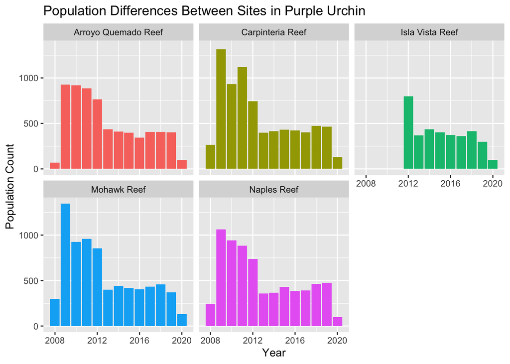

```r
ggplot(data=purple_urchins_summary, aes(x=year, y=n, fill = site_full))+
  geom_col(aes())+
  labs(y = "Population Count",
       x = "Year",
       title= "Population Differences Between Sites in Purple Urchin")+
  facet_wrap(~site_full)+
  theme(legend.position="FALSE")
```

## Conclusion To take a better look at the data, I used a ggplot bar graph and did facet_wrap so each site had their own graph. I thought this could be a possible situation in which a stacked boxplot is useful but as soon as I tried, I decided I didn’t like it, even for an exploratory graph. I removed the legend, added labels and added color to the graph. Across the five sites, it appears that overall purple urchin numbers are declining, possibly due to over harvesting, being outcompeted by other species, or other man-made or natural reasons.